# 8 **Respiration and Yeast Fermentation**

## 8.1 **Introduction: Respiration and Yeast Fermentation**

All living organisms need energy to survive. Plants and animals take energy from the environment and convert it into forms their cells can use. In plants, this begins with photosynthesis, where light energy from the sun is converted into chemical energy stored in glucose. This stored energy then becomes available to living cells through cellular respiration, a series of metabolic pathways that break down glucose and convert its energy into ATP, the usable form of energy for cellular work.

Sugars such as glucose are especially important because they have a large amount of energy stored in their chemical bonds. In organisms that use oxygen, cellular respiration is essentially the reverse of photosynthesis. In this process, glucose reacts with oxygen to produce carbon dioxide, water, and energy:

**C₆H₁₂O₆ + 6O₂ → 6CO₂ + 6H₂O**

During aerobic respiration, oxygen serves as the final electron acceptor in the electron transport chain, allowing cells to produce a large amount of ATP using energy carried by molecules such as NADH and FADH₂.

But when oxygen is unavailable, cells must use alternative pathways to keep producing energy. In these anaerobic conditions, cells rely on fermentation to regenerate NAD⁺ from NADH so that glycolysis can continue producing ATP. Fermentation uses organic molecules as final electron acceptors and does not require oxygen.

There are two common types of fermentation. Lactic acid fermentation occurs in animal muscle cells during intense exercise and in certain bacteria; it converts pyruvate into lactic acid while regenerating NAD⁺:

**C₆H₁₂O₆ → Pyruvic acid + NADH ↔︎ lactic acid + NAD⁺**

Alcohol fermentation, used by yeast, converts pyruvate into ethanol and carbon dioxide while also regenerating NAD⁺:

**C₆H₁₂O₆ → Pyruvic acid → CO₂ + acetaldehyde → ethanol**

Yeast are single-celled eukaryotic fungi that are widely used in industry to produce bread, beer, wine, and various chemicals. In this lab, you will investigate how yeast carry out alcohol fermentation and produce carbon dioxide (CO₂) while breaking down sugars for energy.

During cellular respiration, yeast metabolize sugars and release CO₂ as a byproduct. You will test three monosaccharides—glucose, fructose, and galactose—which all share the same chemical formula (C₆H₁₂O₆) but differ in structure as isomers.

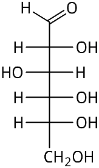

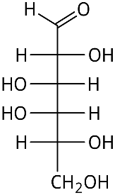

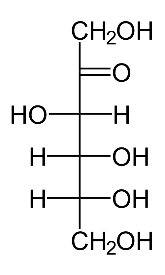

> **Glucose** **Galactose** **Fructose**

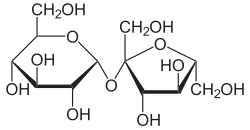

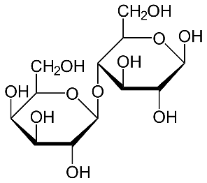

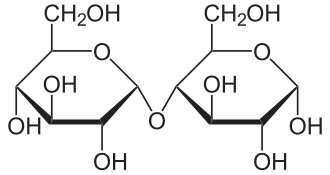

**Sucrose** **Lactose** **Maltose**

By comparing how yeast ferments these different sugars, you will see how molecular structure influences the rate and efficiency of fermentation. Overall, this experiment will help you understand how cells generate energy under anaerobic conditions through processes such as fermentation.

## 8.2 **Materials**

**Substrate experiment**

- China marker
- 7 - 50 ml beakers
- 7 – 15 ml plastic centrifuge tubes
- 7 screw caps for the centrifuge tubes
- 7- I gm parcels of yeast
- 20 ml of the following solutions of the following solutions
  - Water
  - Fructose
  - Glucose
  - Galactose
  - Sucrose
  - Maltose
  - Lactose

**Temperature experiment**

- 5 – 50 ml beakers
- 5 – 15 ml plastic centrifuge tubes
- 20 ml of Glucose of Glucose
- Thermometer
- Water Baths set up for
  - Ice bath; approximately 10<sup>o</sup>C
  - Room temperature, approximately 22<sup>o</sup>C
  - Body temp. Approx 30<sup>o</sup>C
  - Warm, approximately 60<sup>o</sup>C
  - Hot; approximately 90<sup>o</sup>C

## 8.3 **Procedures**

1. **Effects of Substrate on Respiration**

**Table 8.1 Amount of Gas Produced in a Variety of Solutions.**

| **Time, in minutes** | **Water** | **Glucose** | **Fructose** | **Galactose** | **Sucrose** | **Lactose** | **Maltose** |
| --- | --- | --- | --- | --- | --- | --- | --- |
| **0** |  |  |  |  |  |  |  |
| **5** |  |  |  |  |  |  |  |
| **10** |  |  |  |  |  |  |  |
| **15** |  |  |  |  |  |  |  |
| **20** |  |  |  |  |  |  |  |
| **25** |  |  |  |  |  |  |  |
| **30** |  |  |  |  |  |  |  |
| **35** |  |  |  |  |  |  |  |
| **40** |  |  |  |  |  |  |  |
| **45** |  |  |  |  |  |  |  |
| **50** |  |  |  |  |  |  |  |
| **60** |  |  |  |  |  |  |  |
| **Total CO<sub>2</sub> in ml/hr.** |  |  |  |  |  |  |  |

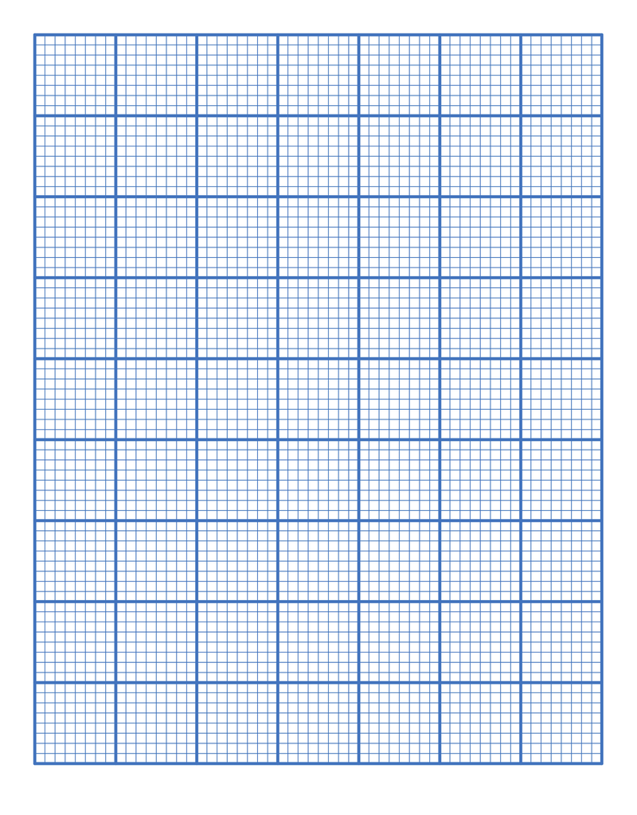

Figure 8.1

2. **Effects of Temperature on Respiration**

You will repeat the experiment to test how temperature affects the rate of respiration. Set up five more beakers and test tubes, but this time use only one sugar, glucose. This part of the lab will help you understand how temperature changes influence yeast respiration.

> **Table 8.2 Amount of Gas Produced in \Varying Temperatures**

| **Time, in minutes** | **Ice** **____ <sup>o</sup>C** | **Room** **____ <sup>o</sup>C** | **Body** **____ <sup>o</sup>C** | **Warm** **____ <sup>o</sup>C** | **Hot** **____ <sup>o</sup>C** |
| --- | --- | --- | --- | --- | --- |
| **0** |  |  |  |  |  |
| **5** |  |  |  |  |  |
| **10** |  |  |  |  |  |
| **15** |  |  |  |  |  |
| **20** |  |  |  |  |  |
| **25** |  |  |  |  |  |
| **30** |  |  |  |  |  |
| **35** |  |  |  |  |  |
| **40** |  |  |  |  |  |
| **45** |  |  |  |  |  |
| **50** |  |  |  |  |  |
| **60** |  |  |  |  |  |
| **Total CO<sub>2</sub> in ml/hr.** |  |  |  |  |  |

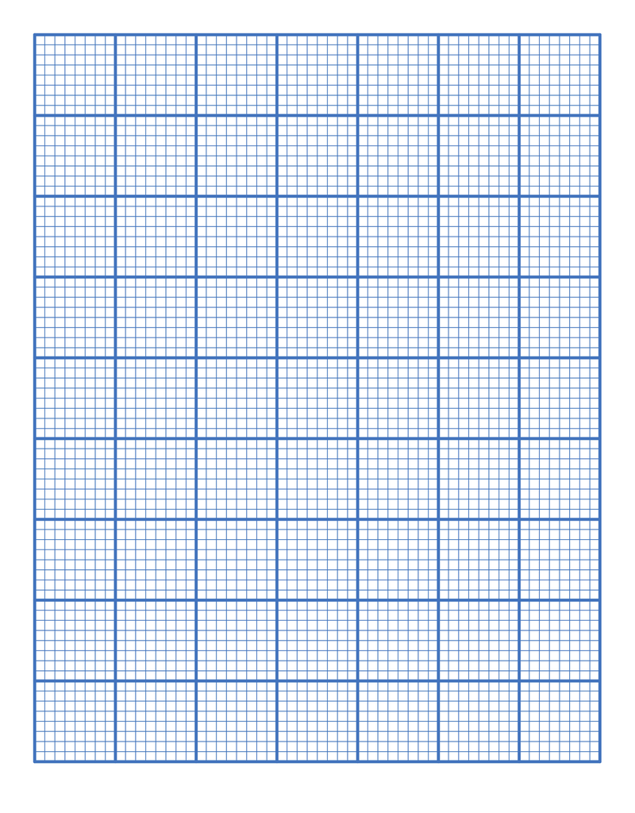

**Figure 8.2**

## 8.4 **Appendix: Respiration and Yeast Fermentation Terms**

| **Term** | **Definition** |
| --- | --- |
| Aerobic Respiration | The process of breaking down glucose using oxygen to produce ATP, carbon dioxide, and water. |
| Alcohol Fermentation | An anaerobic process that converts pyruvate into ethanol and CO2. |
| Anaerobic | A process that occurs without oxygen. |
| ATP | Adenosine triphosphate, the main energy currency of the cell. |
| Carbon Dioxide (CO2) | A gas produced as a byproduct of cellular respiration and fermentation. |
| Cellular Respiration | A series of metabolic reactions that convert glucose into ATP. |
| Electron Transport Chain | A series of proteins that transfer electrons and generate ATP during respiration. |
| Ethanol | Alcohol produced during yeast fermentation. |
| Fermentation | An anaerobic process that allows ATP production by regenerating NAD+ from NADH. |
| Fructose | A monosaccharide sugar that can be used by yeast for fermentation. |
| Galactose | A monosaccharide that must be converted before it can enter glycolysis. |
| Glucose | A primary sugar used by cells to produce energy. |
| Glycolysis | The first step of cellular respiration where glucose is broken into pyruvate. |
| Isomer | Molecules with the same chemical formula but different structures. |
| Lactic Acid Fermentation | An anaerobic process that converts pyruvate into lactic acid. |
| Lactose | A disaccharide composed of glucose and galactose. |
| Maltose | A disaccharide consisting of two glucose molecules. |
| Monosaccharide | A single sugar molecule such as glucose or fructose. |
| NAD+ | An electron carrier required for glycolysis to continue. |
| NADH | A reduced electron carrier that donates electrons in respiration. |
| Oxygen | A gas used as the final electron acceptor in aerobic respiration. |
| Pyruvate | A three-carbon molecule produced during glycolysis. |
| Reaction Rate | The speed at which a biochemical reaction occurs. |
| Respiration | The process by which cells harvest energy from glucose. |
| Substrate | A substance that is metabolized or acted upon in a reaction. |
| Sucrose | A disaccharide composed of glucose and fructose. |
| Temperature | A factor that affects enzyme activity and reaction rate. |
| Yeast | A unicellular fungus used as a model organism for fermentation. |